# Incarceration Trends in the US

Paige Stanley

2022-11-21

## Abstract

This report studies US incarceration data from 1970 to 2018. The charts included reveal the Growth of the US Prison Population, the Growth of the US Prison Population by State, the Distribution of the US Prison Population by Ethnicity, and the Distribution of US Prison Population by State. These charts show the inequalities in the US Prison System and makes inferences in why these are occurring.

## Introduction

The United States has the largest prison population in the world, despite the fact that it only makes up a small portion of the world’s population. Starting around 1970, the United States government introduced the idea of being “tough on crime” in which many policies were introduced to put more people in prison in order to create a safer society. However, instead of lowering crime, this movement resulted in an extremely crowded prison system and a lot of inequality in who was being targeted. Some of these policies include the “Three Strikes Law”, the “War on Drugs”, and the increase use of life sentences. These policies target low income, minority communities. According to the Vera Institute, Black people are twice as likely to be arrested as white people.

This data set is important because it reveals the inequality within the U.S. prison system. The data set shows the differences between men and women incarceration, different ethnicity incarceration, the growth of incarceration, where people are incarcerated the most, etc. The direct stakeholders in this research are the people who gathered the information because it is clear that they want to show inequality and make a difference. The indirect stakeholders are the people in prison who want change for the future as well as better rights. Other indirect stakeholders include politicians who have the power to make change, as well as people like me using the information to reveal inequalities.

The questions I answer in my report are: What is the growth of the U.S. prison population look like from 1970-2018? How do different states compare in their prison population and growth of the prison population from 1970-2018? How do the prison populations of different ethnicities compare to each other? What states have the highest prison populations?

## Data Summary

There are 7.8912389^{6} Black people in prison in the U.S.

There are 1.9259648^{5} Asian American and Pacific Islander people in prison in the U.S.

There are 3.2200135^{6} Latinx people in prison in the U.S.

There are 2.4083796^{5} Native people in prison in the U.S.

There are 8.8147886^{6} white people in prison in the U.S.

## Growth of U.S. Prison Population

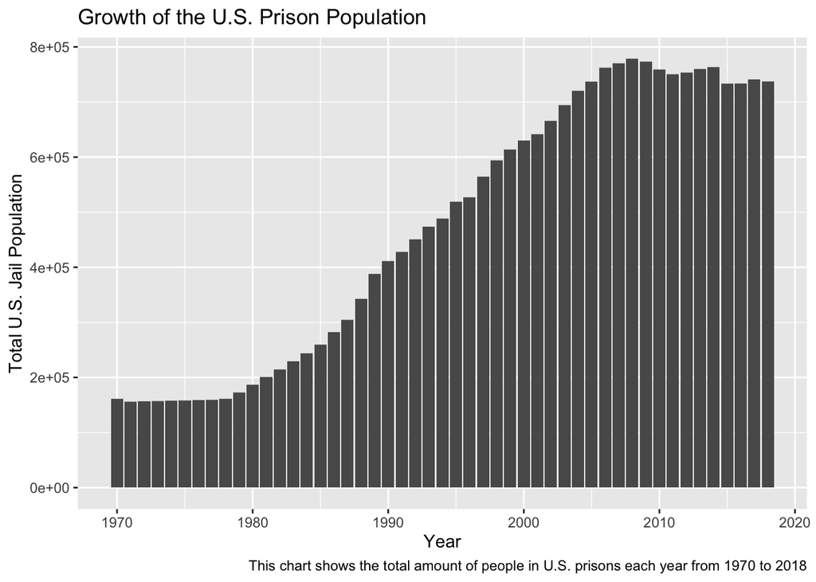

## Growth of Prison Population by State

[figure not shown]

## Distribution of US Prison Population by Ethnicity

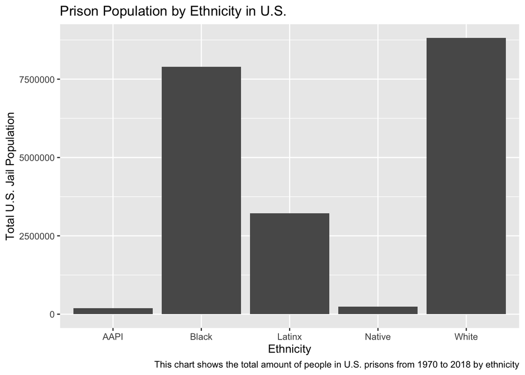

I chose to answer the question of how the prison populations of different ethnicities compare to each other. My chart reveals the drastic difference between how many white and Black people are in prison compared to AAPI and Native people. As mentioned before, Black people are twice as likely to be arrested than white people. A limitation of my chart is that it does not show the proportion of the prison population to the total population of an ethnicity, and it also shows the total amount of people by ethnicity in prison from 1970 to 2018, not just a single year. (I could not figure out how to fix these limitations). From my outside research, I can infer that there is a great inequality between the amount of Black people that are arrested. I found that Black people make up roughly 15% of the U.S. population, while White people make up about 62%. The data shows that there is a fairly similar amount of Black people and white people in prison over the past 48 years.

## Distribution of US Prison Population by State

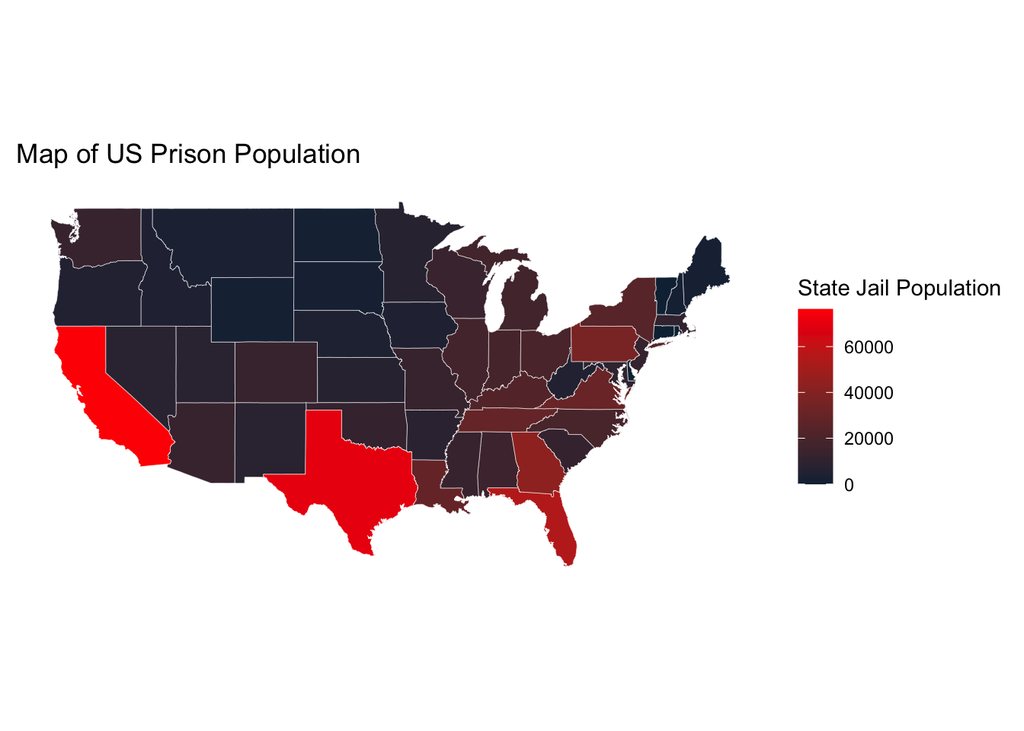

I chose to answer the question of how prison populations vary by states and which states have the highest. I found that California and Texas have the highest prison populations. Followed by Florida, Georgia, and Pennsylvania. The states with the lowest are Wyoming, North Dakota, South Dakota, Maine, etc. While this also follows closely with total population, it is interesting to see that a lot of Southern and Eastern states have high prison populations compared to Northern and Western states. This could be because of stricter laws, party affiliation, etc.